# RProgrammingAssignment3

Marina W. Kim

May 26, 2016

The data for this assignment come from the Hospital Compare web site (http://hospitalcompare.hhs.gov) run by the U.S. Department of Health and Human Services. The purpose of the web site is to provide data and information about the quality of care at over 4,000 Medicare-certified hospitals in the U.S. This dataset es- sentially covers all major U.S. hospitals. This dataset is used for a variety of purposes, including determining whether hospitals should be fined for not providing high quality care to patients (see http://goo.gl/jAXFX for some background on this particular topic).

The Hospital Compare web site contains a lot of data and we will only look at a small subset for this assignment. The zip file for this assignment contains three files • outcome-of-care-measures.csv: Contains information about 30-day mortality and readmission rates for heart attacks, heart failure, and pneumonia for over 4,000 hospitals. • hospital-data.csv: Contains information about each hospital. • Hospital_Revised_Flatfiles.pdf: Descriptions of the variables in each file (i.e the code book).

## 1. Plot the 30-day mortality rates for heart attack

```r
setwd("~/datasciencecoursera/ProgrammingAssignment3") # setting working directory
outcome <- read.csv("outcome-of-care-measures.csv", colClasses = "character")
# head(outcome) ## looking at the first few rows of data (in comment form to reduce output)
ncol(outcome) # number of columns
```

```
## [1] 46
```

```r
nrow(outcome) # number of rows
```

```
## [1] 4706
```

```r
# names(outcome) ## variable names (in comment form to reduce output)
```

Simple histogram of the 30-day death rates from heart attack:

```r
outcome[, 11] <- as.numeric(outcome[, 11])
```

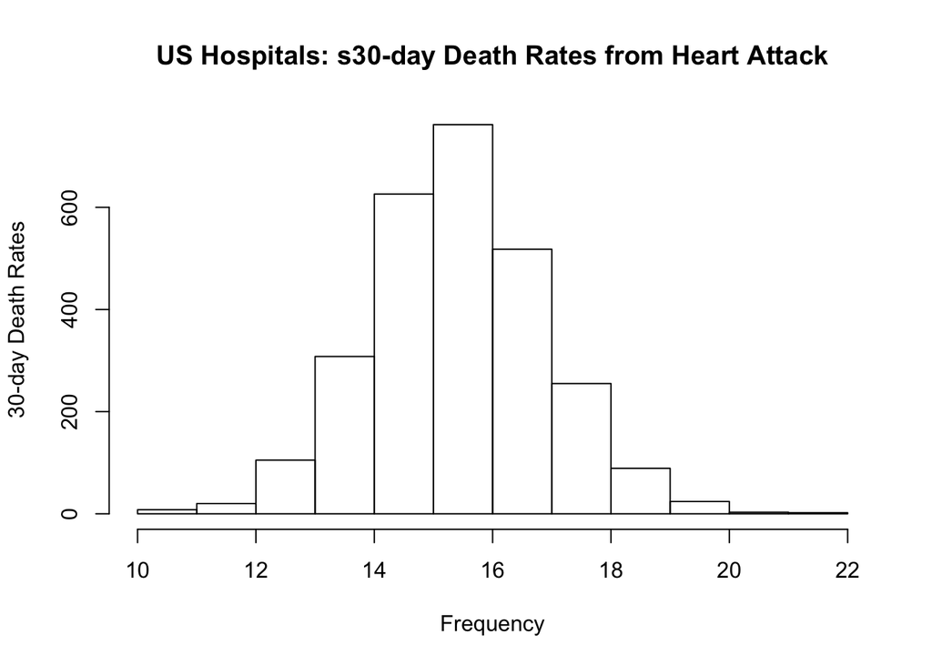

```r
hist(outcome[, 11], xlab = "Frequency", ylab = "30-day Death Rates",
     main = "US Hospitals: s30-day Death Rates from Heart Attack")
```